# Gut microbial diversity during pregnancy and early infancy: an exploratory study in the Indian population

Shreyas V. Kumbhare, Dattatray S. Mongad, Dhrati V. Patangia

25/12/2019

### Background

To study the gut microbiota during pregnancy and infancy, we analyzed gut microbial communities from 20 mother-infant dyads at different stages of pregnancy and early infancy. In total, we analyzed 80 fecal samples for profiling the gut microbial community using 16S rRNA gene-based sequencing. We observed no significant alterations in the gut bacterial diversity during pregnancy, however, significant alterations were observed during the period from birth to six months in infants, with a reduction in *Staphylococcus* and *Enterococcus* and an increase in *Bifidobacterium* and *Streptococcus* with a more stable anaerobic community at the age of six months.

### Preprocessing

The raw reads (paired end reads) were analyzed using the dada2 pipeline (Callahan et al. 2016a). Denoising and pre-processing of the sequence reads were carried out using dada2 pipeline (Callahan et al. 2016a), while reference-based chimera removal was carried out using VSEARCH (Rognes et al. 2016). Taxonomy to the Amplicon Sequence Variants (ASVs) was assigned using SILVA database release 132 (Quast et al. 2013). Diversity analysis was carried out in R (R core team 2017) using phyloseq (Mcmurdie and Holmes 2013) and microbiome package (Lahti et al. 2017). The sparsity of the data was checked, and singletons were removed using the microbiome package (Lahti and Shetty et al., 2017). The phyloseq object was stored as phyloseq.rds and downstream analysis is describe in this document.

```r
setwd("/home/dattatray/Desktop/shreyas/cohort2_reanalysis_scripts/")

library(phangorn)
library(ggplot2)
library(BiocStyle)
library(devtools)
library(gridExtra)
library(knitr)
library(phyloseq)
library(DECIPHER)
library(dplyr)
library(microbiome)
library(vegan)
library(viridis)
library(RColorBrewer)
library(pairwiseAdonis)
library(devtools)
library(pairwiseAdonis)
library(DESeq2)
library(DAtest)
library(metagMisc)
```

```r
set.seed(777)
```

```r
# read phyloseq object
psraw <- readRDS(file = "phyloseq.rds")
psraw
```

```
## phyloseq-class experiment-level object
## otu_table()   OTU Table:         [ 18320 taxa and 80 samples ]
## tax_table()   Taxonomy Table:    [ 18320 taxa by 8 taxonomic ranks ]
```

```r
# Load the metadata into phyloseq object
c2.otu <- otu_table(psraw)
c2.tax <- tax_table(psraw)
meta_table<-read.csv("metadata_cohort2.csv", row.names=1, check.names=FALSE)

psc2 <- phyloseq(otu_table(c2.otu, taxa_are_rows=FALSE),
               sample_data(meta_table),
               tax_table(c2.tax))
psc2
```

```
## phyloseq-class experiment-level object
## otu_table()   OTU Table:         [ 18320 taxa and 80 samples ]
## sample_data() Sample Data:       [ 80 samples by 13 sample variables ]
## tax_table()   Taxonomy Table:    [ 18320 taxa by 8 taxonomic ranks ]
```

### Filtering out unclassified taxa at phyla level and removing unwanted (non-specific) taxa

```r
psc2.filtered <- subset_taxa(psc2, Phylum!= "Euryarchaeota" & Phylum!="NA" & Class!="Chloroplast" & Order!="Mitochondria" & Kingdom!="Archaea")
psc2
```

```
## phyloseq-class experiment-level object
## otu_table()   OTU Table:         [ 18320 taxa and 80 samples ]
## sample_data() Sample Data:       [ 80 samples by 13 sample variables ]
## tax_table()   Taxonomy Table:    [ 18320 taxa by 8 taxonomic ranks ]
```

```r
psc2.filtered
```

```
## phyloseq-class experiment-level object
## otu_table()   OTU Table:         [ 6668 taxa and 80 samples ]
## sample_data() Sample Data:       [ 80 samples by 13 sample variables ]
## tax_table()   Taxonomy Table:    [ 6668 taxa by 8 taxonomic ranks ]
```

### Checking the filetring effect on the library size per sample

```r
df1 <- as.data.frame(sample_data(psc2)) # Put sample_data into a ggplot-friendly data.frame
df1$LibrarySize <- sample_sums(psc2)
Df1<- data.frame(df1)
head(Df1)
```

```
##       SubjectID      Age       BMI      Time.Point Gestational.Age..weeks.
## 01_FT  IFM 01_M 25 Years 23.800000 First Trimester                      12
## 01_M   IFM 01_I        0 11.534030        At birth                    <NA>
## 01_SM  IFM 01_I 6 months 17.740560      Six months                    <NA>
## 01_TT  IFM 01_M 25 Years 24.650000 Third Trimester                      25
## 02_FT  IFM 02_M 31 Years 21.700000 First Trimester                       6
## 02_M   IFM 02_I        0  9.917013        At birth                    <NA>
##          Parity Socioeconomic.status Diet Feeding Birth.Mode Gender
## 01_FT MULTIPARA         LOWER MIDDLE  VEG    <NA>       <NA>   <NA>
## 01_M  MULTIPARA         LOWER MIDDLE <NA>      NF   Cesarean   MALE
## 01_SM MULTIPARA         LOWER MIDDLE  VEG      BF   Cesarean   MALE
## 01_TT MULTIPARA         LOWER MIDDLE  VEG    <NA>       <NA>   <NA>
## 02_FT PRIMIPARA         UPPER MIDDLE BOTH    <NA>       <NA>   <NA>
## 02_M  PRIMIPARA         UPPER MIDDLE <NA>      BF   Cesarean   MALE
##       Feeding_Weaning SampleType LibrarySize
## 01_FT            <NA>     Mother      315735
## 01_M             <NA>     Infant      147715
## 01_SM             YES     Infant      264436
## 01_TT            <NA>     Mother      253848
## 02_FT            <NA>     Mother      301563
## 02_M             <NA>     Infant      417629
```

```r
write.csv(Df1, "before_filtering_taxa.csv")
```

### After filtering

```r
df2 <- as.data.frame(sample_data(psc2.filtered)) # Put sample_data into a ggplot-friendly data.frame
df2$LibrarySize <- sample_sums(psc2.filtered)
Df2<- data.frame(df2)
head(Df2)
```

```
##       SubjectID      Age       BMI      Time.Point Gestational.Age..weeks.
## 01_FT  IFM 01_M 25 Years 23.800000 First Trimester                      12
## 01_M   IFM 01_I        0 11.534030        At birth                    <NA>
## 01_SM  IFM 01_I 6 months 17.740560      Six months                    <NA>
## 01_TT  IFM 01_M 25 Years 24.650000 Third Trimester                      25
## 02_FT  IFM 02_M 31 Years 21.700000 First Trimester                       6
## 02_M   IFM 02_I        0  9.917013        At birth                    <NA>
##          Parity Socioeconomic.status Diet Feeding Birth.Mode Gender
## 01_FT MULTIPARA         LOWER MIDDLE  VEG    <NA>       <NA>   <NA>
## 01_M  MULTIPARA         LOWER MIDDLE <NA>      NF   Cesarean   MALE
## 01_SM MULTIPARA         LOWER MIDDLE  VEG      BF   Cesarean   MALE
## 01_TT MULTIPARA         LOWER MIDDLE  VEG    <NA>       <NA>   <NA>
## 02_FT PRIMIPARA         UPPER MIDDLE BOTH    <NA>       <NA>   <NA>
## 02_M  PRIMIPARA         UPPER MIDDLE <NA>      BF   Cesarean   MALE
##       Feeding_Weaning SampleType LibrarySize
## 01_FT            <NA>     Mother      145434
## 01_M             <NA>     Infant      121779
## 01_SM             YES     Infant      209681
## 01_TT            <NA>     Mother      119241
## 02_FT            <NA>     Mother      130723
## 02_M             <NA>     Infant      176861
```

```r
write.csv(Df2, "after_filtering_taxa.csv")
```

### separating out infants and mothers samples

```r
ps.infant <- subset_samples(psc2.filtered,SampleType%in%c("Infant"))
ps.infant <- prune_taxa(taxa_sums(ps.infant)>0, ps.infant)
ps.infant
```

```
## phyloseq-class experiment-level object
## otu_table()   OTU Table:         [ 4646 taxa and 40 samples ]
## sample_data() Sample Data:       [ 40 samples by 13 sample variables ]
## tax_table()   Taxonomy Table:    [ 4646 taxa by 8 taxonomic ranks ]
```

```r
ps.mother <- subset_samples(psc2.filtered,SampleType%in%c("Mother"))
ps.mother <- prune_taxa(taxa_sums(ps.mother)>0, ps.mother)
ps.mother
```

```
## phyloseq-class experiment-level object
## otu_table()   OTU Table:         [ 2856 taxa and 40 samples ]
## sample_data() Sample Data:       [ 40 samples by 13 sample variables ]
## tax_table()   Taxonomy Table:    [ 2856 taxa by 8 taxonomic ranks ]
```

### Compute prevalence and abundance of ASVs for infant samples

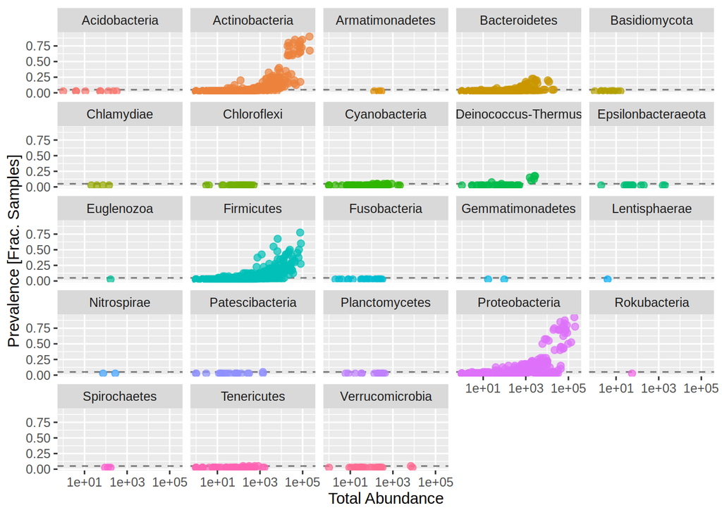

```r
# Compute prevalence of each feature, store as data.frame
prevdf = apply(X = otu_table(ps.infant),
        MARGIN = ifelse(taxa_are_rows(ps.infant), yes = 1, no = 2),FUN = function(x){sum(x > 0)})
# Add taxonomy and total read counts to this data.frame
prevdf = data.frame(Prevalence = prevdf,
                      TotalAbundance = taxa_sums(ps.infant),
                      tax_table(ps.infant))
# plotting
ggplot(prevdf, aes(TotalAbundance, Prevalence / nsamples(ps.infant),color=Phylum)) +
  # Include a guess for parameter
  geom_hline(yintercept = 0.05, alpha = 0.5, linetype = 2) + geom_point(size = 2, alpha = 0.7) +
  scale_x_log10() +  xlab("Total Abundance") + ylab("Prevalence [Frac. Samples]") +
  facet_wrap(~Phylum) + theme(legend.position="none")
```

### Compute prevalence and abundance of ASVs for mother samples

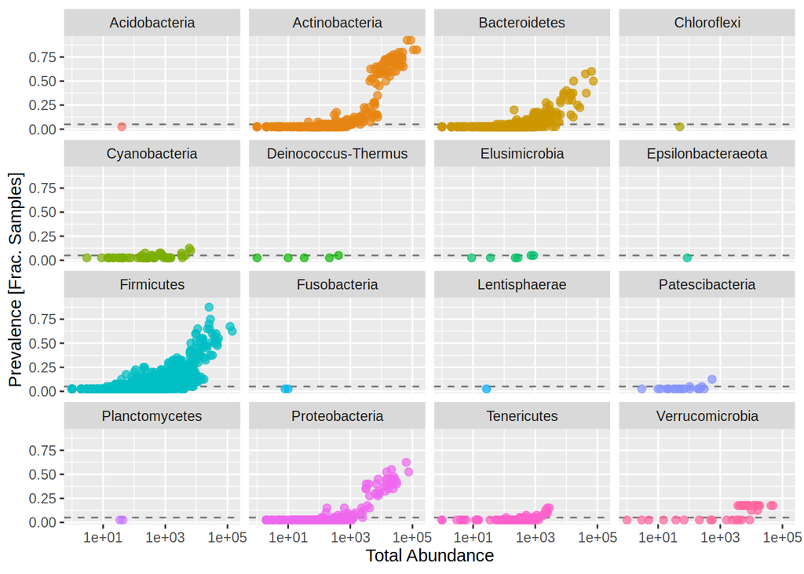

```r
# Compute prevalence of each feature, store as data.frame
prevdf1 = apply(X = otu_table(ps.mother),
                 MARGIN = ifelse(taxa_are_rows(ps.mother), yes = 1, no = 2),
                 FUN = function(x){sum(x > 0)})
# Add taxonomy and total read counts to this data.frame
prevdf1 = data.frame(Prevalence = prevdf1,
                      TotalAbundance = taxa_sums(ps.mother),
                      tax_table(ps.mother))
# plotting
ggplot(prevdf1, aes(TotalAbundance, Prevalence / nsamples(ps.mother),color=Phylum)) +
  # Include a guess for parameter
  geom_hline(yintercept = 0.05, alpha = 0.5, linetype = 2) + geom_point(size = 2, alpha = 0.7) +
  scale_x_log10() +  xlab("Total Abundance") + ylab("Prevalence [Frac. Samples]") +
  facet_wrap(~Phylum) + theme(legend.position="none")
```

#### Based on the above results we decided to filter out the reads using a prevalence cut off of 0.10 for both maternal and infant samples.

### Filtering low prevalence ASVs

```r
psinfant.final <- phyloseq_filter_prevalence(ps.infant, prev.trh = 0.10, abund.trh =NULL)
ps.infant
```

```
## phyloseq-class experiment-level object
## otu_table()   OTU Table:         [ 4646 taxa and 40 samples ]
## sample_data() Sample Data:       [ 40 samples by 13 sample variables ]
## tax_table()   Taxonomy Table:    [ 4646 taxa by 8 taxonomic ranks ]
```

```r
psinfant.final
```

```
## phyloseq-class experiment-level object
## otu_table()   OTU Table:         [ 417 taxa and 40 samples ]
## sample_data() Sample Data:       [ 40 samples by 13 sample variables ]
## tax_table()   Taxonomy Table:    [ 417 taxa by 8 taxonomic ranks ]
```

```r
#checking effect of filtering on library size
df3 <- as.data.frame(sample_data(psinfant.final)) # Put sample_data into a ggplot-friendly data.frame
df3$LibrarySize <- sample_sums(psinfant.final)
Df3<- data.frame(df3)
head(Df3)
```

```
##       SubjectID      Age       BMI Time.Point Gestational.Age..weeks.    Parity
## 01_M   IFM 01_I        0 11.534030   At birth                    <NA> MULTIPARA
## 01_SM  IFM 01_I 6 months 17.740560 Six months                    <NA> MULTIPARA
## 02_M   IFM 02_I        0  9.917013   At birth                    <NA> PRIMIPARA
## 02_SM  IFM 02_I 6 months 18.180860 Six months                    <NA> PRIMIPARA
## 03M    IFM 03_I        0 12.240000   At birth                    <NA> PRIMIPARA
## 03_SM  IFM 03_I 6 months 14.013380 Six months                    <NA> PRIMIPARA
##       Socioeconomic.status Diet Feeding Birth.Mode Gender Feeding_Weaning
## 01_M          LOWER MIDDLE <NA>      NF   Cesarean   MALE            <NA>
## 01_SM         LOWER MIDDLE  VEG      BF   Cesarean   MALE             YES
## 02_M          UPPER MIDDLE <NA>      BF   Cesarean   MALE            <NA>
## 02_SM         UPPER MIDDLE BOTH      BF   Cesarean   MALE             YES
## 03M                  UPPER <NA>      NF   Cesarean FEMALE            <NA>
## 03_SM                UPPER  VEG      BF   Cesarean FEMALE             YES
##       SampleType LibrarySize
## 01_M      Infant      121074
## 01_SM     Infant      199358
## 02_M      Infant       50091
## 02_SM     Infant      135711
## 03M       Infant      467690
## 03_SM     Infant      101186
```

```r
write.csv(Df3, "after_prev_filt_infants.csv")
```

```r
psmother.final <- phyloseq_filter_prevalence(ps.mother, prev.trh = 0.10, abund.trh =NULL)
ps.mother
```

```
## phyloseq-class experiment-level object
## otu_table()   OTU Table:         [ 2856 taxa and 40 samples ]
## sample_data() Sample Data:       [ 40 samples by 13 sample variables ]
## tax_table()   Taxonomy Table:    [ 2856 taxa by 8 taxonomic ranks ]
```

```r
psmother.final
```

```
## phyloseq-class experiment-level object
## otu_table()   OTU Table:         [ 538 taxa and 40 samples ]
## sample_data() Sample Data:       [ 40 samples by 13 sample variables ]
## tax_table()   Taxonomy Table:    [ 538 taxa by 8 taxonomic ranks ]
```

```r
#checking effect of filtering on library size
df4 <- as.data.frame(sample_data(psmother.final)) # Put sample_data into a ggplot-friendly data.frame
df4$LibrarySize <- sample_sums(psmother.final)
Df4<- data.frame(df4)
head(Df4)
```

```
##       SubjectID      Age   BMI      Time.Point Gestational.Age..weeks.
## 01_FT  IFM 01_M 25 Years 23.80 First Trimester                      12
## 01_TT  IFM 01_M 25 Years 24.65 Third Trimester                      25
## 02_FT  IFM 02_M 31 Years 21.70 First Trimester                       6
## 02_TT  IFM 02_M 31 Years 22.97 Third Trimester         34 Weeks 5 days
## 03_FT  IFM 03_M 31 Years 25.30 First Trimester                      12
## 03_TT  IFM 03_M 31 Years 26.74 Third Trimester         24 Weeks 4 days
##          Parity Socioeconomic.status Diet Feeding Birth.Mode Gender
## 01_FT MULTIPARA         LOWER MIDDLE  VEG    <NA>       <NA>   <NA>
## 01_TT MULTIPARA         LOWER MIDDLE  VEG    <NA>       <NA>   <NA>
## 02_FT PRIMIPARA         UPPER MIDDLE BOTH    <NA>       <NA>   <NA>
## 02_TT PRIMIPARA         UPPER MIDDLE BOTH    <NA>       <NA>   <NA>
## 03_FT PRIMIPARA                UPPER BOTH    <NA>       <NA>   <NA>
## 03_TT PRIMIPARA                UPPER BOTH    <NA>       <NA>   <NA>
##       Feeding_Weaning SampleType LibrarySize
## 01_FT            <NA>     Mother      137070
## 01_TT            <NA>     Mother      109012
## 02_FT            <NA>     Mother      101967
## 02_TT            <NA>     Mother      171701
## 03_FT            <NA>     Mother       87611
## 03_TT            <NA>     Mother       79609
```

```r
write.csv(Df4, "after_prev_filt_mothers.csv")
```

### Alpha diversity plots

#### for infant samples

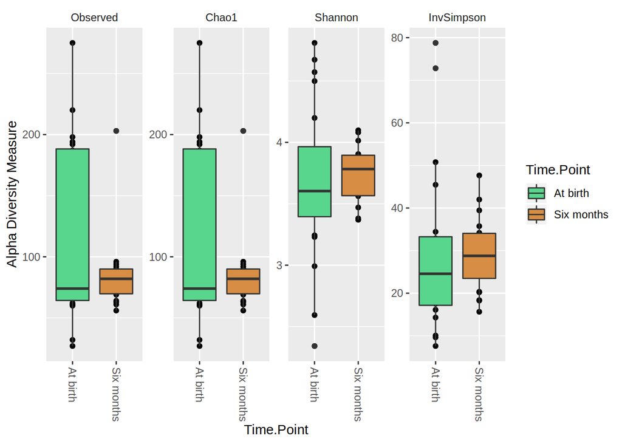

```r
div.all.1 <- estimate_richness(psinfant.final)
write.csv(div.all.1, "alpha_div_infant.all .csv")
alpha.ps1 <- plot_richness(psinfant.final, x="Time.Point", measures=c("Observed", "Chao1", "Shannon", "InvSimpson")) + geom_boxplot(aes(fill=Time.Point))
p1 <- alpha.ps1 + scale_fill_manual(values = c("#58d68d",  "#D78D43")) + theme(strip.background = element_rect(fill="white"))
print(p1)
```

### pairwise comparison of alpha diversity indices/measures between two time points

```r
pairwise.wilcox.test(div.all.1$Observed, sample_data(psinfant.final)$Time.Point,p.adjust.method = "fdr")
```

```
##
##  Pairwise comparisons using Wilcoxon rank sum test
##
## data:  div.all.1$Observed and sample_data(psinfant.final)$Time.Point
##
##            At birth
## Six months 0.96
##
## P value adjustment method: fdr
```

```r
pairwise.wilcox.test(div.all.1$Chao1, sample_data(psinfant.final)$Time.Point, p.adjust.method = "fdr")
```

```
##
##  Pairwise comparisons using Wilcoxon rank sum test
##
## data:  div.all.1$Chao1 and sample_data(psinfant.final)$Time.Point
##
##            At birth
## Six months 0.96
##
## P value adjustment method: fdr
```

```r
pairwise.wilcox.test(div.all.1$Shannon, sample_data(psinfant.final)$Time.Point, p.adjust.method = "fdr")
```

```
##
##  Pairwise comparisons using Wilcoxon rank sum test
##
## data:  div.all.1$Shannon and sample_data(psinfant.final)$Time.Point
##
##            At birth
## Six months 0.51
##
## P value adjustment method: fdr
```

```r
pairwise.wilcox.test(div.all.1$InvSimpson, sample_data(psinfant.final)$Time.Point, p.adjust.method = "fdr")
```

```
##
##  Pairwise comparisons using Wilcoxon rank sum test
##
## data:  div.all.1$InvSimpson and sample_data(psinfant.final)$Time.Point
##
##            At birth
## Six months 0.35
##
## P value adjustment method: fdr
```

#### for mother samples

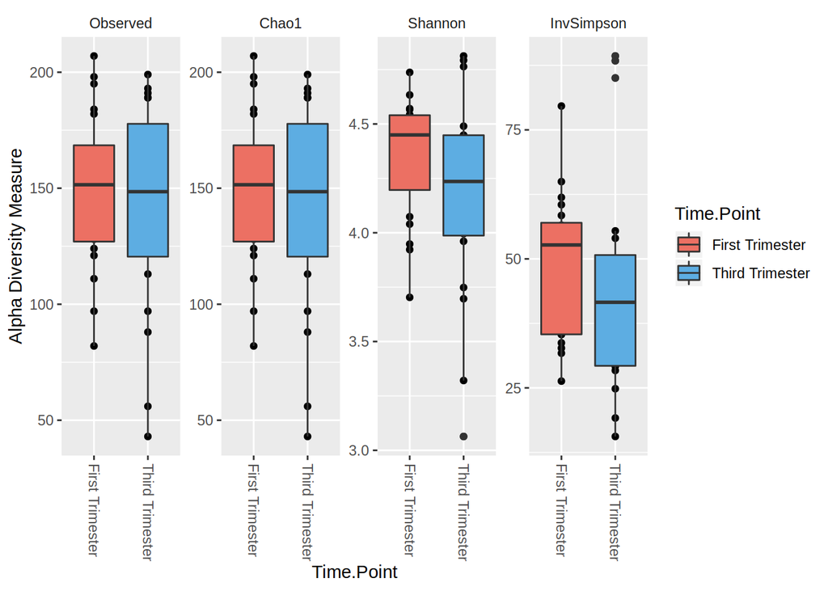

```r
div.all.2 <- estimate_richness(psmother.final)
write.csv(div.all.2, "alpha_div_mother.all.csv")
alpha.ps2 <- plot_richness(psmother.final, x="Time.Point", measures=c("Observed", "Chao1", "Shannon", "InvSimpson")) + geom_boxplot(aes(fill=Time.Point))
p2 <- alpha.ps2 + scale_fill_manual(values = c("#ec7063", "#5dade2")) + theme(strip.background = element_rect(fill="white"))
print(p2)
```

## pairwise comparison for mother samples

```r
pairwise.wilcox.test(div.all.2$Observed, sample_data(psmother.final)$Time.Point, p.adjust.method = "fdr")
```

```
##
##  Pairwise comparisons using Wilcoxon rank sum test
##
## data:  div.all.2$Observed and sample_data(psmother.final)$Time.Point
##
##                 First Trimester
## Third Trimester 0.75
##
## P value adjustment method: fdr
```

```r
pairwise.wilcox.test(div.all.2$Chao1, sample_data(psmother.final)$Time.Point, p.adjust.method = "fdr")
```

```
##
##  Pairwise comparisons using Wilcoxon rank sum test
##
## data:  div.all.2$Chao1 and sample_data(psmother.final)$Time.Point
##
##                 First Trimester
## Third Trimester 0.75
##
## P value adjustment method: fdr
```

```r
pairwise.wilcox.test(div.all.2$Shannon, sample_data(psmother.final)$Time.Point, p.adjust.method = "fdr")
```

```
##
##  Pairwise comparisons using Wilcoxon rank sum test
##
## data:  div.all.2$Shannon and sample_data(psmother.final)$Time.Point
##
##                 First Trimester
## Third Trimester 0.17
##
## P value adjustment method: fdr
```

```r
pairwise.wilcox.test(div.all.2$InvSimpson, sample_data(psmother.final)$Time.Point, p.adjust.method = "fdr")
```

```
##
##  Pairwise comparisons using Wilcoxon rank sum test
##
## data:  div.all.2$InvSimpson and sample_data(psmother.final)$Time.Point
##
##                 First Trimester
## Third Trimester 0.06
##
## P value adjustment method: fdr
```

### Compositional transformation and bar chart at phyla level

#### for infant samples

```r
# meconium samples
ps.meco <- subset_samples(psinfant.final,Time.Point%in%c("At birth"))
ps.meco <- prune_taxa(taxa_sums(ps.meco)>0, ps.meco)
ps.meco
```

```
## phyloseq-class experiment-level object
## otu_table()   OTU Table:         [ 410 taxa and 20 samples ]
## sample_data() Sample Data:       [ 20 samples by 13 sample variables ]
## tax_table()   Taxonomy Table:    [ 410 taxa by 8 taxonomic ranks ]
```

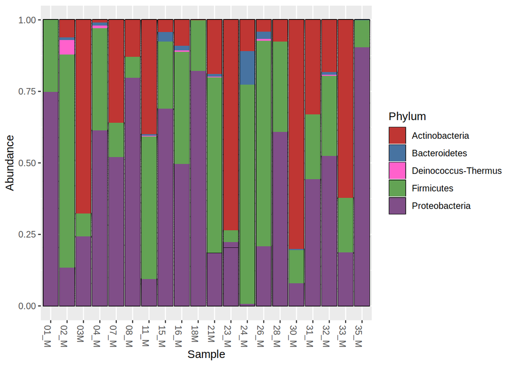

```r
psmeco.rel <- microbiome::transform(ps.meco, "compositional")
# plotting
plot_bar(psmeco.rel, fill = "Phylum") + geom_bar(aes(fill=Phylum), stat="identity") + scale_fill_manual(values = c("#bf3633", "#4773a1", "#ff61cc", "#63a354", "#804e88"))
```

```r
# six month samples
ps.six <- subset_samples(psinfant.final,Time.Point%in%c("Six months"))
ps.six
```

```
## phyloseq-class experiment-level object
## otu_table()   OTU Table:         [ 417 taxa and 20 samples ]
## sample_data() Sample Data:       [ 20 samples by 13 sample variables ]
## tax_table()   Taxonomy Table:    [ 417 taxa by 8 taxonomic ranks ]
```

```r
ps.six <- prune_taxa(taxa_sums(ps.six)>0, ps.six)
ps.six
```

```
## phyloseq-class experiment-level object
## otu_table()   OTU Table:         [ 348 taxa and 20 samples ]
## sample_data() Sample Data:       [ 20 samples by 13 sample variables ]
## tax_table()   Taxonomy Table:    [ 348 taxa by 8 taxonomic ranks ]
```

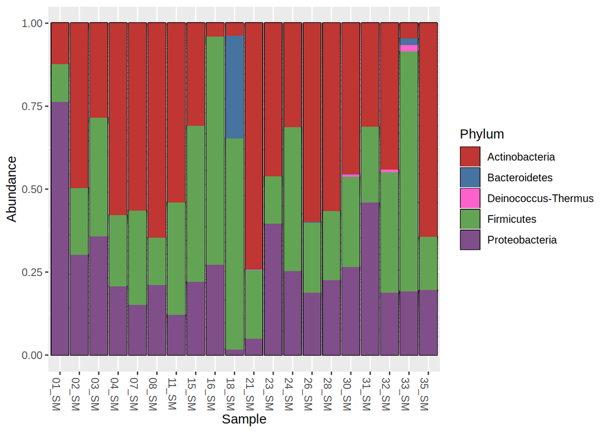

```r
pssix.rel <- microbiome::transform(ps.six, "compositional")
plot_bar(pssix.rel, fill = "Phylum") + geom_bar(aes(fill=Phylum), stat="identity", position = "stack") + scale_fill_manual(values = c("#bf3633", "#4773a1", "#ff61cc", "#63a354", "#804e88"))
```

#### for maternal samples

```r
# first trimester
ps.first <- subset_samples(psmother.final,Time.Point%in%c("First Trimester"))
ps.first
```

```
## phyloseq-class experiment-level object
## otu_table()   OTU Table:         [ 538 taxa and 20 samples ]
## sample_data() Sample Data:       [ 20 samples by 13 sample variables ]
## tax_table()   Taxonomy Table:    [ 538 taxa by 8 taxonomic ranks ]
```

```r
ps.first <- prune_taxa(taxa_sums(ps.first)>0, ps.first)
ps.first
```

```
## phyloseq-class experiment-level object
## otu_table()   OTU Table:         [ 535 taxa and 20 samples ]
## sample_data() Sample Data:       [ 20 samples by 13 sample variables ]
## tax_table()   Taxonomy Table:    [ 535 taxa by 8 taxonomic ranks ]
```

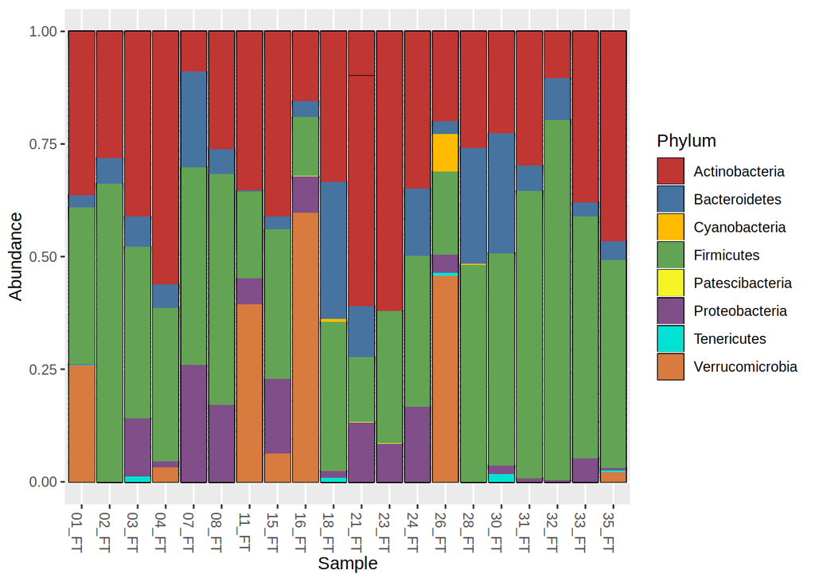

```r
psfirst.rel <- microbiome::transform(ps.first, "compositional")
plot_bar(psfirst.rel, fill = "Phylum") + geom_bar(aes(fill=Phylum), stat="identity") + scale_fill_manual(values = c("#bf3633", "#4773a1", "#ffbb00", "#63a354", "#f7f425", "#804e88", "#00e3d4", "#d87b3e"))
```

```r
# third trimester
ps.third <- subset_samples(psmother.final,Time.Point%in%c("Third Trimester"))
ps.third
```

```
## phyloseq-class experiment-level object
## otu_table()   OTU Table:         [ 538 taxa and 20 samples ]
## sample_data() Sample Data:       [ 20 samples by 13 sample variables ]
## tax_table()   Taxonomy Table:    [ 538 taxa by 8 taxonomic ranks ]
```

```r
ps.third <- prune_taxa(taxa_sums(ps.third)>0, ps.third)
ps.third
```

```
## phyloseq-class experiment-level object
## otu_table()   OTU Table:         [ 535 taxa and 20 samples ]
## sample_data() Sample Data:       [ 20 samples by 13 sample variables ]
## tax_table()   Taxonomy Table:    [ 535 taxa by 8 taxonomic ranks ]
```

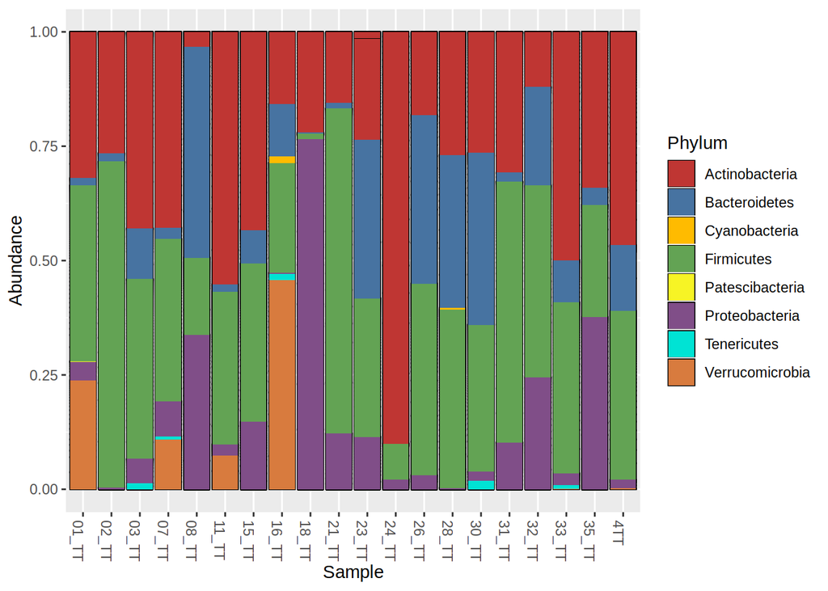

```r
psthird.rel <- microbiome::transform(ps.third, "compositional")
plot_bar(psthird.rel, fill = "Phylum") + geom_bar(aes(fill=Phylum), stat="identity") + scale_fill_manual(values = c("#bf3633", "#4773a1", "#ffbb00", "#63a354", "#f7f425", "#804e88", "#00e3d4", "#d87b3e"))
```

### Ordination analysis

#### for infant samples

For ordination analysis rank tranformation was performed as described by Callahan et al. 2016

```r
ps_ranks1 <- psinfant.final
abund1 <- otu_table(ps_ranks1)
abund_ranks1 <- t(apply(abund1, 1, rank))
write.table(abund_ranks1,file = "abund1_total.txt",sep = "\t")

abund_ranks1 <- abund_ranks1 - 375 # 90% of observed ASVs
abund_ranks1[abund_ranks1 < 1] <- 1
otu_table(ps_ranks1) <- otu_table(abund_ranks1, taxa_are_rows = F)
ps_ranks1
```

```
## phyloseq-class experiment-level object
## otu_table()   OTU Table:         [ 417 taxa and 40 samples ]
## sample_data() Sample Data:       [ 40 samples by 13 sample variables ]
## tax_table()   Taxonomy Table:    [ 417 taxa by 8 taxonomic ranks ]
```

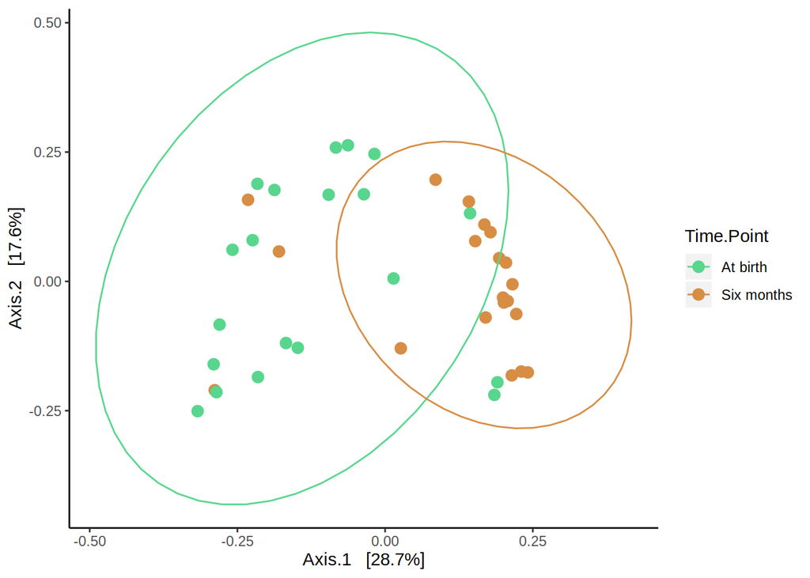

```r
# plotting ordination using Bray curtis distances
ps_ranks1_plot <- plot_ordination(ps_ranks1, ordinate(ps_ranks1, "MDS", "bray"), color = "Time.Point") + geom_point(size = 3)

ps_ranks1_plot + scale_color_manual(values=c("#58d68d",  "#D78D43")) + stat_ellipse(type = "t") + theme(panel.grid.major = element_blank(), panel.grid.minor = element_blank(), panel.background = element_blank(), axis.line = element_line(colour = "black"))
```

#### Significance testing for ordination analysis using PERMANOVA

```r
pairwise.adonis(phyloseq::distance(ps_ranks1, method = "bray"), sample_data(psinfant.final)$Time.Point, perm = 999, p.adjust.m = "fdr")
```

```
##                    pairs Df SumsOfSqs  F.Model        R2 p.value p.adjusted sig
## 1 At birth vs Six months  1 0.7329452 6.115098 0.1386169   0.001      0.001  **
```

#### Beta dispersion analysis (inter individual variation)

```r
psinfants_dist <- phyloseq::distance(ps_ranks1, method = "bray")
sampledf1 <- data.frame(sample_data(ps_ranks1))
beta1 <- betadisper(psinfants_dist, sampledf1$Time.Point, bias.adjust = TRUE)
permutest(beta1, pairwise = TRUE, p.adjust.methods= "fdr")
```

```
##
## Permutation test for homogeneity of multivariate dispersions
## Permutation: free
## Number of permutations: 999
##
## Response: Distances
##           Df  Sum Sq  Mean Sq      F N.Perm Pr(>F)
## Groups     1 0.27316 0.273165 20.144    999  0.001 ***
## Residuals 38 0.51531 0.013561
## ---
## Signif. codes:  0 '***' 0.001 '**' 0.01 '*' 0.05 '.' 0.1 ' ' 1
##
## Pairwise comparisons:
## (Observed p-value below diagonal, permuted p-value above diagonal)
##              At birth Six months
## At birth                   0.001
## Six months 6.4737e-05
```

#### for mother samples

```r
ps_ranks2 <- psmother.final
abund2 <- otu_table(ps_ranks2)
abund_ranks2 <- t(apply(abund2, 1, rank))
write.table(abund_ranks2,file = "abund2_total.txt",sep = "\t")

abund_ranks2 <- abund_ranks2 - 484 # 90% of observed ASVs
abund_ranks2[abund_ranks2 < 1] <- 1
otu_table(ps_ranks2) <- otu_table(abund_ranks2, taxa_are_rows = F)
ps_ranks2
```

```
## phyloseq-class experiment-level object
## otu_table()   OTU Table:         [ 538 taxa and 40 samples ]
## sample_data() Sample Data:       [ 40 samples by 13 sample variables ]
## tax_table()   Taxonomy Table:    [ 538 taxa by 8 taxonomic ranks ]
```

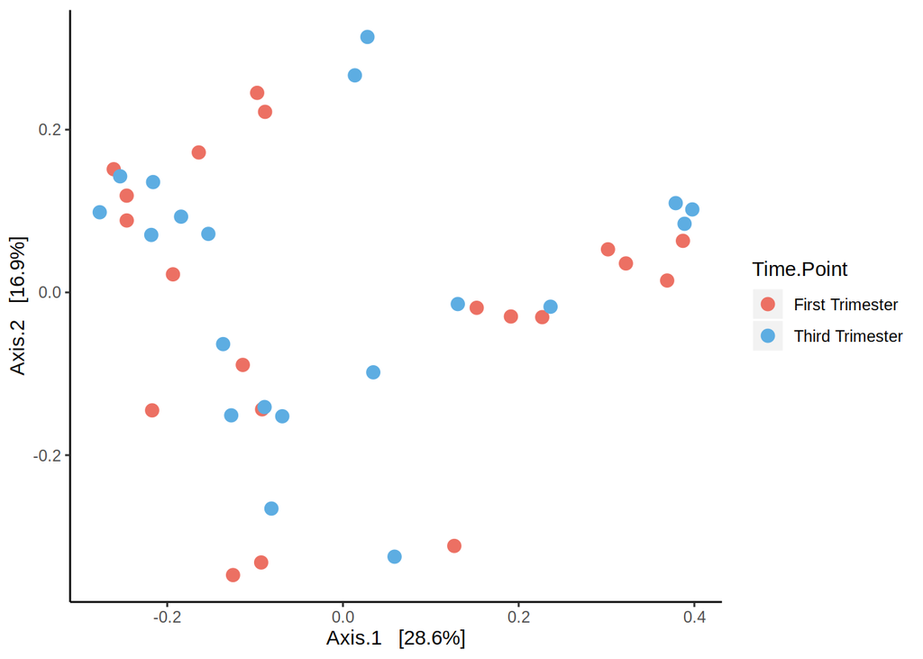

```r
# plotting
ps_ranks2_plot <- plot_ordination(ps_ranks2, ordinate(ps_ranks2, "MDS", "bray"), color = "Time.Point") + geom_point(size = 3)

ps_ranks2_plot + scale_color_manual(values=c("#ec7063", "#5dade2")) + theme(panel.grid.major = element_blank(), panel.grid.minor = element_blank(), panel.background = element_blank(), axis.line = element_line(colour = "black"))
```

#### Significance testing for ordination analysis using PERMANOVA

```r
pairwise.adonis(phyloseq::distance(ps_ranks2, method = "bray"), sample_data(psmother.final)$Time.Point, perm = 999, p.adjust.m = "fdr")
```

```
##                                pairs Df SumsOfSqs   F.Model         R2 p.value
## 1 First Trimester vs Third Trimester  1 0.0711248 0.4227856 0.01100351   0.925
##   p.adjusted sig
## 1      0.925
```

#### Beta dispersion analysis (inter individual variation)

```r
psmothers_dist <- phyloseq::distance(ps_ranks2, method = "bray")
sampledf2 <- data.frame(sample_data(ps_ranks2))
beta2 <- betadisper(psmothers_dist, sampledf2$Time.Point, bias.adjust = TRUE)
permutest(beta2, pairwise = TRUE, p.adjust.methods= "fdr")
```

```
##
## Permutation test for homogeneity of multivariate dispersions
## Permutation: free
## Number of permutations: 999
##
## Response: Distances
##           Df  Sum Sq   Mean Sq     F N.Perm Pr(>F)
## Groups     1 0.00043 0.0004298 0.058    999  0.808
## Residuals 38 0.28176 0.0074148
##
## Pairwise comparisons:
## (Observed p-value below diagonal, permuted p-value above diagonal)
##                 First Trimester Third Trimester
## First Trimester                           0.804
## Third Trimester         0.81103
```

### Differential abundance testing

To assess the differences between two groups, i.e., first trimester vs. the third trimester (mothers) and at birth vs. six months (infants), variance stabilization method was employed using the ‘DESeq2’ package (Love et al., 2014) as described previously (McMurdie and Holmes 2014) and differential abundance of the ASVs were calculated using the ‘DAtest’ package (Russel et al., 2018) and expressed in Log2fold change and significance testing was carried out using paired Wilcoxon rank sum test (to compare between time points) or Kruskal-Wallis test (for unpaired comparison) with BH based FDR correction.

#### for infant samples

```r
ps_dds = phyloseq_to_deseq2(psinfant.final, ~SubjectID + Time.Point) # Paired design
gm_mean = function(x, na.rm = TRUE){
  exp(sum(log(x[x > 0]), na.rm = na.rm) / length(x))
}
geoMeans = apply(counts(ps_dds), 1, gm_mean)
ps_dds = estimateSizeFactors(ps_dds, geoMeans = geoMeans)
ps_dds = estimateDispersions(ps_dds)
abund = getVarianceStabilizedData(ps_dds)
## You can use this transformed values to replace the values in the main phyloseq object for e.g. here replace values in psfinal.infant and then perform the wilcox sum rank test. Please make sure you create a new object and not replace the original phyloseq.
write.csv(abund, "vst_infant.csv")
```

#### for maternal samples

```r
ps_dds2 = phyloseq_to_deseq2(psmother.final, ~SubjectID + Time.Point) # Paired design
gm_mean = function(x, na.rm = TRUE){
  exp(sum(log(x[x > 0]), na.rm = na.rm) / length(x))
}
geoMeans = apply(counts(ps_dds2), 1, gm_mean)
ps_dds2 = estimateSizeFactors(ps_dds2, geoMeans = geoMeans)
ps_dds2 = estimateDispersions(ps_dds2)
abund2 = getVarianceStabilizedData(ps_dds2)
write.csv(abund2, "vst_mother.csv")
```

### Differential abundance testing using DAtest package

Creating a copy of phyloseq objects with VST transformed values

```r
# for infant samples
psinfant.vst <- psinfant.final
otu_table(psinfant.vst) <- otu_table(abund, taxa_are_rows = TRUE)
psinfant.vst
```

```
## phyloseq-class experiment-level object
## otu_table()   OTU Table:         [ 417 taxa and 40 samples ]
## sample_data() Sample Data:       [ 40 samples by 13 sample variables ]
## tax_table()   Taxonomy Table:    [ 417 taxa by 8 taxonomic ranks ]
```

```r
# for mother samples
psmother.vst <- psmother.final
otu_table(psmother.vst) <- otu_table(abund2, taxa_are_rows = TRUE)
psmother.vst
```

```
## phyloseq-class experiment-level object
## otu_table()   OTU Table:         [ 538 taxa and 40 samples ]
## sample_data() Sample Data:       [ 40 samples by 13 sample variables ]
## tax_table()   Taxonomy Table:    [ 538 taxa by 8 taxonomic ranks ]
```

#### Applying wilcoxon sum rank test on these phyloseq objects using pairwise comparisons.

Wilcoxon sum rank test was chosen for pairwise non-parametric testing.

```r
# for infant samples
infant.res2 <- allDA(psinfant.vst, predictor= "Time.Point", paired = "SubjectID", relative = FALSE, p.adj = "fdr", alpha = 0.01)
```

```
## Running 6 methods...
##
```

```r
# check results for wilcoxon sum rank test
# head(infant.res2$results$wil)
write.csv(infant.res2$results$wil, "infants_diffAbund.csv", row.names = TRUE)

# for mother samples
mother.res <- allDA(psmother.vst, predictor= "Time.Point", paired = "SubjectID", relative = FALSE, p.adj = "fdr", alpha = 0.01)
```

```
## Running 6 methods...
##
```

```r
# check results for wilcoxon sum rank test
# head(mother.res$results$wil)
write.csv(mother.res$results$wil, "mothers_diffAbund.csv", row.names = TRUE)
```

Above output files contain only sequences of ASVs. So, we added taxonomy of respective ASVs from phyloseq object.

```r
# for infant samples
tax<- data.frame(psinfant.vst@tax_table@.Data)
abund<- otu_table(psinfant.vst)
tax$Feature <- rownames(abund)

DA_infant<-tax %>%  left_join(infant.res2$results$wil) %>%
arrange(pval.adj)
write.csv(DA_infant, "diff_asv_infant_final.csv")

# for mother samples
tax<- data.frame(psmother.vst@tax_table@.Data)
abund3<- otu_table(psmother.vst)
tax$Feature <- rownames(abund3)

DA_mother<-tax %>%  left_join(mother.res$results$wil) %>%
arrange(pval.adj)
write.csv(DA_mother, "diff_asv_mother_final.csv")
```

### Log fold change plot for differentially abundant ASVs for infants

```r
wilcox.out.infant <- read.table(file = 'diff_asv_infant_final.csv',header = T,sep = ',')
head(wilcox.out.infant)
```

```
##   X  Kingdom         Phylum          Class             Order             Family
## 1 1 Bacteria Actinobacteria Actinobacteria Bifidobacteriales Bifidobacteriaceae
## 2 2 Bacteria Actinobacteria Actinobacteria Bifidobacteriales Bifidobacteriaceae
## 3 3 Bacteria Actinobacteria Actinobacteria Bifidobacteriales Bifidobacteriaceae
## 4 4 Bacteria Actinobacteria Actinobacteria Bifidobacteriales Bifidobacteriaceae
## 5 5 Bacteria     Firmicutes        Bacilli   Lactobacillales   Streptococcaceae
## 6 6 Bacteria Actinobacteria Actinobacteria Bifidobacteriales Bifidobacteriaceae
##             Genus Species Species.1
## 1 Bifidobacterium      NA        NA
## 2 Bifidobacterium      NA        NA
## 3 Bifidobacterium      NA        NA
## 4 Bifidobacterium      NA        NA
## 5   Streptococcus      NA        NA
## 6 Bifidobacterium      NA        NA
##                                                                                                                                                                                                                                                                                               Feature
## 1  TGCCAGCAGCCGCGGTAATACGTAGGGTGCAAGCGTTATCCGGAATTATTGGGCGTAAAG…
## 2 TGCCAGCAGCCGCGGTAATACGTAGGGTGCAAGCGTTATCCGGAATTATTGGGCGTAAAG…
## 3 TGCCAGCAGCCGCGGTAATACGTAGGGTGCAAGCGTTATCCGGAATTATTGGGCGTAAAG…
## 4  TGCCAGCAGCCGCGGTAATACGTAGGGTGCAAGCGTTATCCGGAATTATTGGGCGTAAAG…
## 5   TGCCAGCAGCCGCGGTAATACGTAGGTCCCGAGCGTTGTCCGGATTTATTGGGCGTAAAG…
## 6 GTGCCAGCCGCCGCGGTAATACGTAGGGTGCAAGCGTTATCCGGAATTATTGGGCGTAAA…
##           pval   pval.adj    log2FC            ordering       Method
## 1 0.0010897172 0.03309333 1.1504302 Six months>At birth Wilcox (wil)
## 2 0.0007787981 0.03309333 0.9997159 Six months>At birth Wilcox (wil)
## 3 0.0007787981 0.03309333 0.9780398 Six months>At birth Wilcox (wil)
## 4 0.0005801974 0.03309333 1.1485310 Six months>At birth Wilcox (wil)
## 5 0.0011974130 0.03309333 1.2443737 Six months>At birth Wilcox (wil)
## 6 0.0005855560 0.03309333 0.8131075 Six months>At birth Wilcox (wil)
```

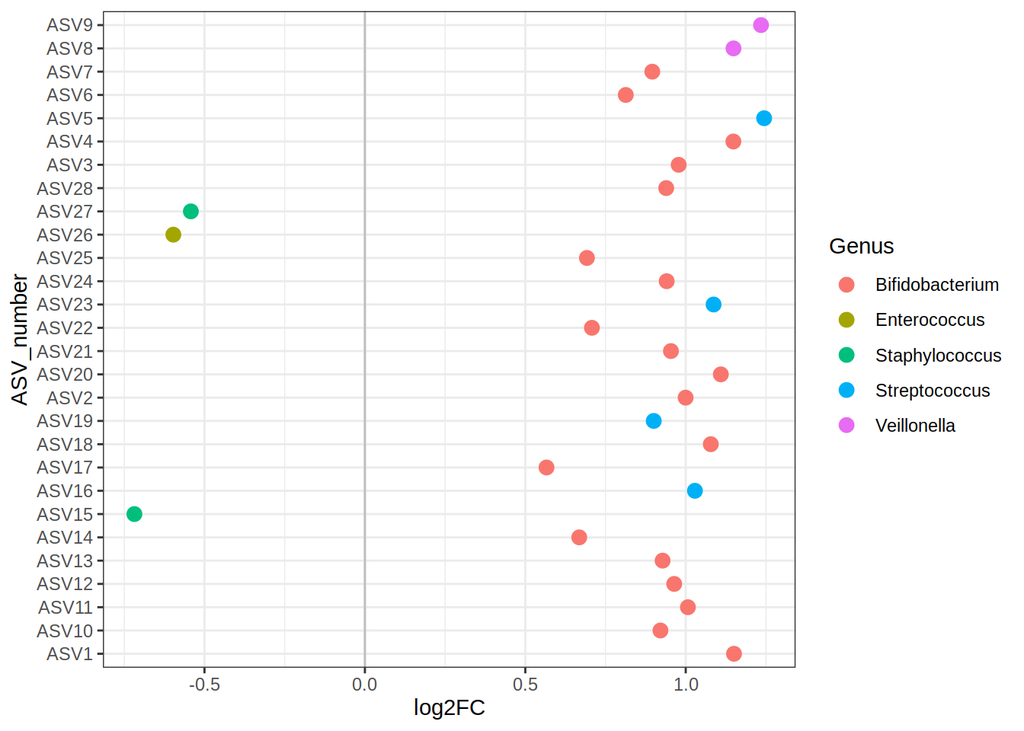

```r
# filter features having p.adj <= 0.05
wilcox.out.infant <- wilcox.out.infant[wilcox.out.infant$pval.adj<=0.05,]

# add ASV numbers
wilcox.out.infant$ASV_number <- paste0('ASV',1:length(wilcox.out.infant$Feature),sep='')

# plotting
ggplot(data = wilcox.out.infant, mapping = aes(x = log2FC,y = ASV_number, color= Genus)) + geom_point(size=3) + geom_vline(xintercept = 0,color="grey") + theme_bw()
```

#### Testing prevalence and abundance of differentially abundant ASVs

```r
# creating sequence table of differentially abundant ASVs for meconium and six month samples
seqtab.infant.diff.asv.6m <- t(as.data.frame(otu_table(pssix.rel)))[as.character(wilcox.out.infant$Feature),]
seqtab.infant.diff.asv.meco <- t(as.data.frame(otu_table(psmeco.rel)))[as.character(wilcox.out.infant$Feature),]

# calculate mean relative abundance of differentially abundant ASVs
means.of.asv.6m<- as.data.frame(apply(seqtab.infant.diff.asv.6m,1,mean))
means.of.asv.meco <- as.data.frame(apply(seqtab.infant.diff.asv.meco,1,mean))

# calculate prevalence of differentially abundant ASVs
prev.asv.6m <- as.data.frame(rowSums(seqtab.infant.diff.asv.6m != 0)/dim(seqtab.infant.diff.asv.6m)[2])
prev.asv.meco <- as.data.frame(rowSums(seqtab.infant.diff.asv.meco != 0)/dim(seqtab.infant.diff.asv.meco)[2])

# creating dataframe of abundance and prevalence of differentially abundant ASVs
prev_n_abund_diff_asv <- data.frame('ASV_number'=wilcox.out.infant$ASV_number,'Mean_rel_abund_at_birth' = means.of.asv.meco[,1],'Mean_rel_abund_six_month' = means.of.asv.6m[,1],'Prevalence_at_birth'=prev.asv.meco[,1],'Prevalence_six_month'=prev.asv.6m[,1])

# packing information and summarizing
row.names(prev_n_abund_diff_asv) <- wilcox.out.infant$Feature
row.names(wilcox.out.infant) <- wilcox.out.infant$Feature
summary_diff_asv <- merge(wilcox.out.infant,prev_n_abund_diff_asv)
head(summary_diff_asv)
```

```
##   ASV_number  X  Kingdom         Phylum          Class             Order
## 1       ASV1  1 Bacteria Actinobacteria Actinobacteria Bifidobacteriales
## 2      ASV10 10 Bacteria Actinobacteria Actinobacteria Bifidobacteriales
## 3      ASV11 11 Bacteria Actinobacteria Actinobacteria Bifidobacteriales
## 4      ASV12 12 Bacteria Actinobacteria Actinobacteria Bifidobacteriales
## 5      ASV13 13 Bacteria Actinobacteria Actinobacteria Bifidobacteriales
## 6      ASV14 14 Bacteria Actinobacteria Actinobacteria Bifidobacteriales
##               Family           Genus Species Species.1
## 1 Bifidobacteriaceae Bifidobacterium      NA        NA
## 2 Bifidobacteriaceae Bifidobacterium      NA        NA
## 3 Bifidobacteriaceae Bifidobacterium      NA        NA
## 4 Bifidobacteriaceae Bifidobacterium      NA        NA
## 5 Bifidobacteriaceae Bifidobacterium      NA        NA
## 6 Bifidobacteriaceae Bifidobacterium      NA        NA
##                                                                                                                                                                                                                                                                                               Feature
```

[output cut: 27 more lines]

#### As there were no significant differences at ASV level for maternal samples, we agglomerated data at genus & phylum level, transformed the data and carried out differential abundance testing.

```r
# agglomeration at genus level
psmother_glom <- tax_glom(psmother.final, "Genus", NArm = TRUE)
psmother_glom
```

```
## phyloseq-class experiment-level object
## otu_table()   OTU Table:         [ 65 taxa and 40 samples ]
## sample_data() Sample Data:       [ 40 samples by 13 sample variables ]
## tax_table()   Taxonomy Table:    [ 65 taxa by 8 taxonomic ranks ]
```

```r
# VST transformation of the agglomerated phyloseq object
mother.glom.vst = phyloseq_to_deseq2(psmother_glom, ~SubjectID + Time.Point) # Paired design
gm_mean = function(x, na.rm = TRUE){
  exp(sum(log(x[x > 0]), na.rm = na.rm) / length(x))
}
geoMeans = apply(counts(mother.glom.vst), 1, gm_mean)
mother.glom.vst = estimateSizeFactors(mother.glom.vst, geoMeans = geoMeans)
mother.glom.vst = estimateDispersions(mother.glom.vst)
abund.mother.glom = getVarianceStabilizedData(mother.glom.vst)

# replacing vst transformed counts in phyloseq object
psmother.vst.glom <- psmother_glom
otu_table(psmother.vst.glom) <- otu_table(abund.mother.glom, taxa_are_rows = TRUE)

# differential abundance testing
mother.glom <- allDA(psmother.vst.glom, predictor= "Time.Point", paired = "SubjectID", relative = FALSE, p.adj = "fdr", alpha = 0.01)
```

```
## Running 6 methods...
##
```

```r
# head(mother.glom$results$wil)
write.csv(mother.glom$results$wil, "mothers_diffAbund_genus.csv", row.names = TRUE)
```

```r
# agglomeration at phylum level
psmother.phylum.glom <- tax_glom(psmother.final, "Phylum", NArm = TRUE)
psmother.phylum.glom
```

```
## phyloseq-class experiment-level object
## otu_table()   OTU Table:         [ 8 taxa and 40 samples ]
## sample_data() Sample Data:       [ 40 samples by 13 sample variables ]
## tax_table()   Taxonomy Table:    [ 8 taxa by 8 taxonomic ranks ]
```

```r
# VST transformation of the agglomerated phyloseq object
mother.phy.glom.vst = phyloseq_to_deseq2(psmother.phylum.glom, ~SubjectID + Time.Point) # Paired design
gm_mean = function(x, na.rm = TRUE){
  exp(sum(log(x[x > 0]), na.rm = na.rm) / length(x))
}
geoMeans = apply(counts(mother.phy.glom.vst), 1, gm_mean)
mother.phy.glom.vst = estimateSizeFactors(mother.phy.glom.vst, geoMeans = geoMeans)
mother.phy.glom.vst = estimateDispersions(mother.phy.glom.vst)
abund.mother.phy.glom = getVarianceStabilizedData(mother.phy.glom.vst)

# replacing vst transformed counts in phyloseq object
psmother.phy.vst.glom <- psmother.phylum.glom
otu_table(psmother.phy.vst.glom) <- otu_table(abund.mother.phy.glom, taxa_are_rows = TRUE)

# differential abundance testing
mother.phy.glom <- allDA(psmother.phy.vst.glom, predictor= "Time.Point", paired = "SubjectID", relative = FALSE, p.adj = "fdr", alpha = 0.01)
```

```
## Running 6 methods...
##
```

```r
# head(mother.phy.glom$results$wil)
write.csv(mother.phy.glom$results$wil, "mothers_diffAbund_phylum.csv", row.names = TRUE)
```

No significant differences at ASV, phylum or genus level were observed in maternal samples when compared between time points.

### Analysing influence of other recorded factors on gut bacterial diversity

#### Maternal factors-Maternal microbiome

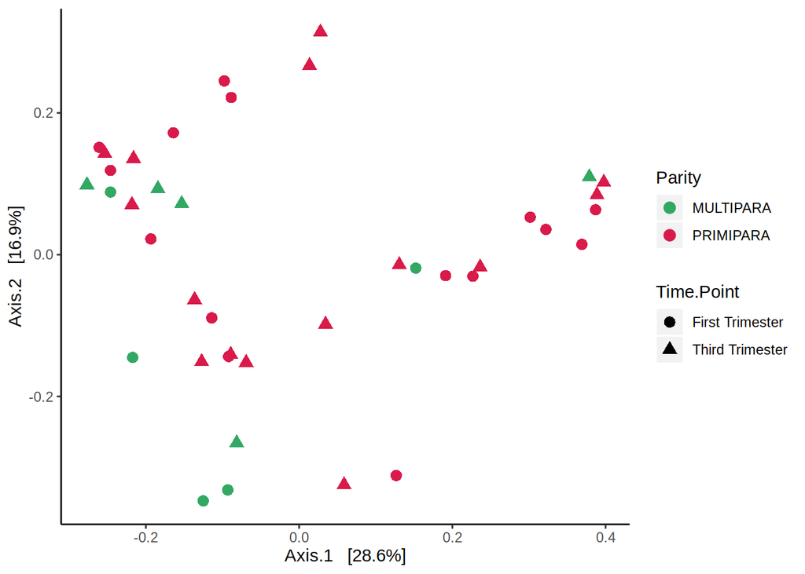

```r
# Maternal microbiome and parity
# Using the previous rank tranformed phyloseq objects
ps_ranks3_plot <- plot_ordination(ps_ranks2, ordinate(ps_ranks2, "MDS", "bray"), color = "Parity", shape = "Time.Point") + geom_point(size = 3)

ps_ranks3_plot + scale_color_manual(values=c("#32a864", "#d91a4a")) + theme(panel.grid.major = element_blank(), panel.grid.minor = element_blank(), panel.background = element_blank(), axis.line = element_line(colour = "black"))
```

```r
# Significance testing for ordination analysis (not pairwise)
metadata1 <- as(sample_data(ps_ranks2), "data.frame")
adonis(phyloseq::distance(ps_ranks2, method = "bray")~Parity, data = metadata1, p.adjust.methods= "fdr", permutations = 999)
```

```
##
## Call:
## adonis(formula = phyloseq::distance(ps_ranks2, method = "bray") ~      Parity, data = metadata1, permutations = 999, p.adjust.methods = "fdr")
##
## Permutation: free
## Number of permutations: 999
##
## Terms added sequentially (first to last)
##
##           Df SumsOfSqs MeanSqs F.Model     R2 Pr(>F)
## Parity     1    0.2365 0.23654  1.4434 0.0366  0.166
## Residuals 38    6.2273 0.16388         0.9634
## Total     39    6.4638                 1.0000
```

```r
# Beta dispersion analysis
beta3 <- betadisper(psmothers_dist, sampledf2$Parity, bias.adjust = TRUE)
permutest(beta3, p.adjust.methods= "fdr")
```

```
##
## Permutation test for homogeneity of multivariate dispersions
## Permutation: free
## Number of permutations: 999
##
## Response: Distances
##           Df  Sum Sq   Mean Sq      F N.Perm Pr(>F)
## Groups     1 0.01475 0.0147537 1.5024    999   0.24
## Residuals 38 0.37317 0.0098202
```

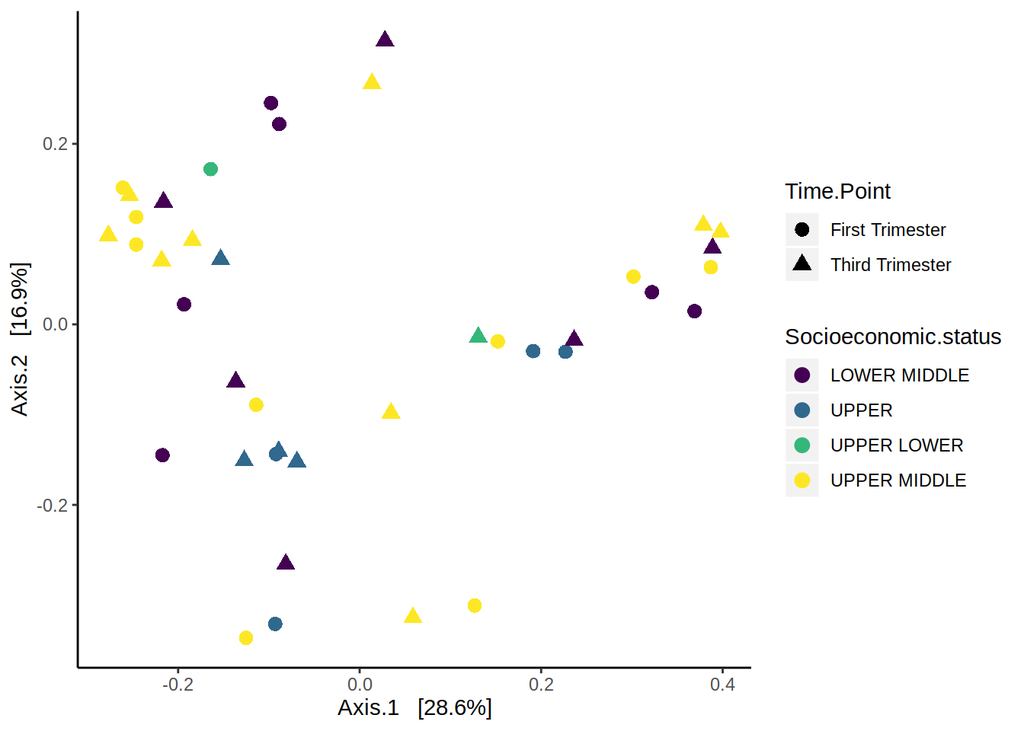

```r
# Mothers and socioeconomic status
ps_ranks4_plot <- plot_ordination(ps_ranks2, ordinate(ps_ranks2, "MDS", "bray"), color = "Socioeconomic.status", shape = "Time.Point") + geom_point(size = 3)

ps_ranks4_plot + scale_color_viridis(discrete = TRUE) + theme(panel.grid.major = element_blank(), panel.grid.minor = element_blank(), panel.background = element_blank(), axis.line = element_line(colour = "black"))
```

```r
# Significance testing for ordination analysis (not pairwise)
adonis(phyloseq::distance(ps_ranks2, method = "bray")~Socioeconomic.status, data = metadata1, p.adjust.methods= "fdr", permutations = 999)
```

```
##
## Call:
## adonis(formula = phyloseq::distance(ps_ranks2, method = "bray") ~      Socioeconomic.status, data = metadata1, permutations = 999,      p.adjust.methods = "fdr")
##
## Permutation: free
## Number of permutations: 999
##
## Terms added sequentially (first to last)
##
##                      Df SumsOfSqs MeanSqs F.Model      R2 Pr(>F)
## Socioeconomic.status  3    0.4663 0.15542 0.93289 0.07213  0.542
## Residuals            36    5.9976 0.16660         0.92787
## Total                39    6.4638                 1.00000
```

```r
# Beta dispersion analysis
beta4 <- betadisper(psmothers_dist, sampledf2$Socioeconomic.status, bias.adjust = TRUE)
permutest(beta4, p.adjust.methods= "fdr")
```

```
##
## Permutation test for homogeneity of multivariate dispersions
## Permutation: free
## Number of permutations: 999
##
## Response: Distances
##           Df  Sum Sq   Mean Sq      F N.Perm Pr(>F)
## Groups     3 0.00812 0.0027051 0.2582    999  0.845
## Residuals 36 0.37720 0.0104777
```

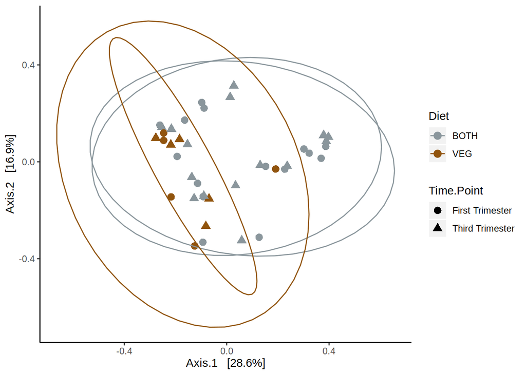

```r
# Mothers and dietary pattern
ps_ranks5_plot <- plot_ordination(ps_ranks2, ordinate(ps_ranks2, "MDS", "bray"), color = "Diet", shape = "Time.Point") + geom_point(size = 3)

ps_ranks5_plot + scale_color_manual(values = c("#8a969c", "#91540d")) + theme(panel.grid.major = element_blank(), panel.grid.minor = element_blank(), panel.background = element_blank(), axis.line = element_line(colour = "black")) + stat_ellipse(type = "t")
```

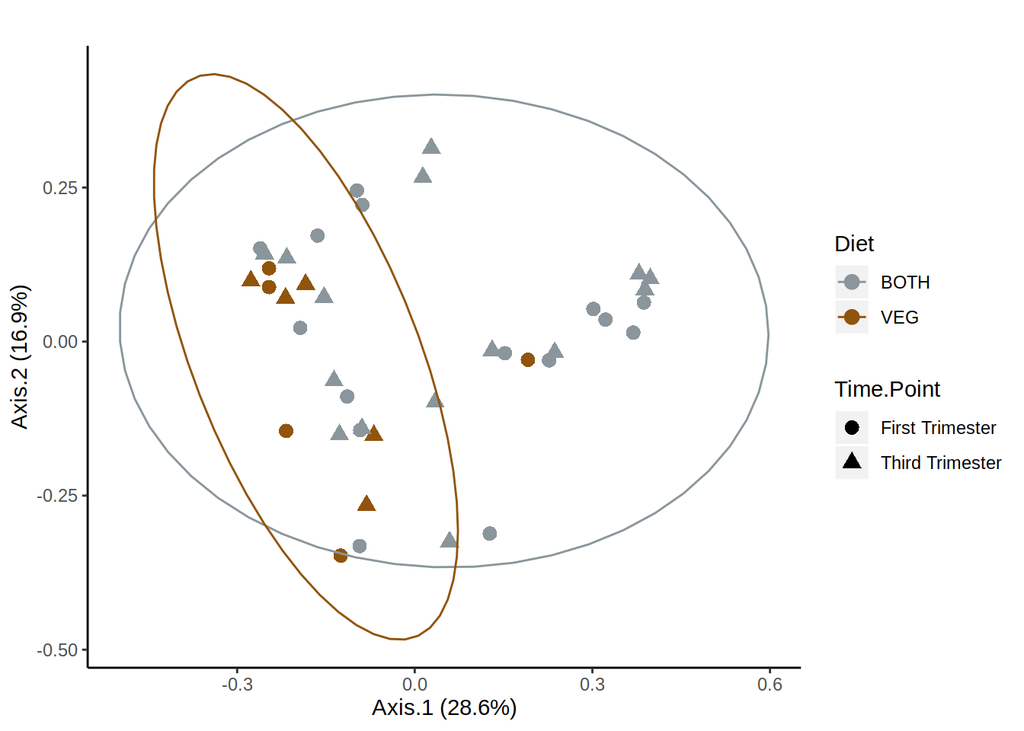

```r
# rewriting ggplot function for adding stat-ellipse specifically for diet variables
ps_ranks5_plot <- plot_ordination(ps_ranks2, ordinate(ps_ranks2, "MDS", "bray"))
pt_ord_data_m1 <- as.data.frame(ps_ranks5_plot$data)
ggplot(pt_ord_data_m1, aes(Axis.1, Axis.2)) + geom_point(aes(color=Diet, shape=Time.Point), size=3) + labs(x="Axis.1 (28.6%)",y="Axis.2 (16.9%)") + ggtitle("") + theme(legend.position = "right") + stat_ellipse(type = "t", linetype = 1, aes(group=Diet, color=Diet)) +
  # scale_color_manual(values = c(col_blind2))
  scale_color_manual(values = c("#8a969c", "#91540d")) + theme(panel.grid.major = element_blank(), panel.grid.minor = element_blank(), panel.background = element_blank(), axis.line = element_line(colour = "black"))
```

```r
# Significance testing for ordination analysis (not pairwise)
adonis(phyloseq::distance(ps_ranks2, method = "bray")~Diet, data = metadata1, p.adjust.methods= "fdr", permutations = 999)
```

```
##
## Call:
## adonis(formula = phyloseq::distance(ps_ranks2, method = "bray") ~      Diet, data = metadata1, permutations = 999, p.adjust.methods = "fdr")
##
## Permutation: free
## Number of permutations: 999
##
## Terms added sequentially (first to last)
##
##           Df SumsOfSqs MeanSqs F.Model      R2 Pr(>F)
## Diet       1    0.3666 0.36657  2.2845 0.05671  0.021 *
## Residuals 38    6.0973 0.16045         0.94329
## Total     39    6.4638                 1.00000
## ---
## Signif. codes:  0 '***' 0.001 '**' 0.01 '*' 0.05 '.' 0.1 ' ' 1
```

```r
# Beta dispersion analysis
beta5 <- betadisper(psmothers_dist, sampledf2$Diet, bias.adjust = TRUE)
permutest(beta5, p.adjust.methods= "fdr")
```

```
##
## Permutation test for homogeneity of multivariate dispersions
## Permutation: free
## Number of permutations: 999
##
## Response: Distances
##           Df   Sum Sq  Mean Sq      F N.Perm Pr(>F)
## Groups     1 0.085761 0.085761 13.584    999  0.001 ***
## Residuals 38 0.239901 0.006313
## ---
## Signif. codes:  0 '***' 0.001 '**' 0.01 '*' 0.05 '.' 0.1 ' ' 1
```

#### Infant factors - infant microbiome

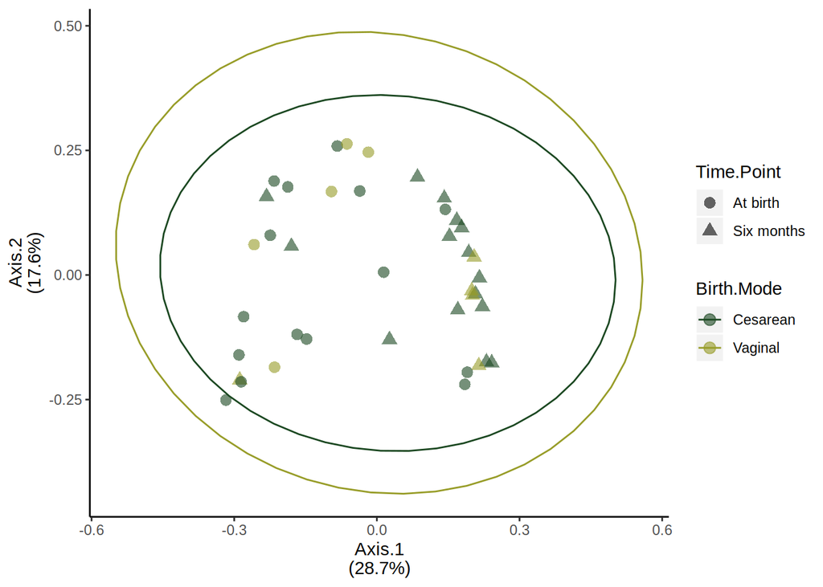

```r
# infant birth mode
ps_ranks6_plot <- plot_ordination(ps_ranks1, ordinate(ps_ranks1, "MDS", "bray"))
pt_ord_data_m2 <- as.data.frame(ps_ranks6_plot$data)
ggplot(pt_ord_data_m2, aes(Axis.1, Axis.2)) + geom_point(aes(color=Birth.Mode, shape=Time.Point), size=3, alpha=0.6) + labs(x="Axis.1\n(28.7%)",y="Axis.2\n(17.6%)") + theme(legend.position = "right") + stat_ellipse(type = "t", linetype = 1, aes(group=Birth.Mode, color=Birth.Mode)) +
  # scale_color_manual(values = c(col_blind2))
  scale_color_manual(values = c("#1a4720", "#979c27")) + theme(panel.grid.major = element_blank(), panel.grid.minor = element_blank(), panel.background = element_blank(), axis.line = element_line(colour = "black"))
```

The influence of other infant factors was masked due to huge variation in community structure between meconium and six month samples (as seen above). Meaning, time point has a stronger effect here, hence, we decided to analyse the influence of these factors seperately at birth and six months.

```r
# infant birth mode - meconium samples
ps_ranks4 <- ps.meco
abund4 <- otu_table(ps_ranks4)
abund_ranks4 <- t(apply(abund4, 1, rank))
write.table(abund_ranks4,file = "abund4_total.txt",sep = "\t")

# rank tranformation
abund_ranks4 <- abund_ranks4 - 369 # 90% of observed ASVs
abund_ranks4[abund_ranks4 < 1] <- 1
otu_table(ps_ranks4) <- otu_table(abund_ranks4, taxa_are_rows = F)
ps_ranks4
```

```
## phyloseq-class experiment-level object
## otu_table()   OTU Table:         [ 410 taxa and 20 samples ]
## sample_data() Sample Data:       [ 20 samples by 13 sample variables ]
## tax_table()   Taxonomy Table:    [ 410 taxa by 8 taxonomic ranks ]
```

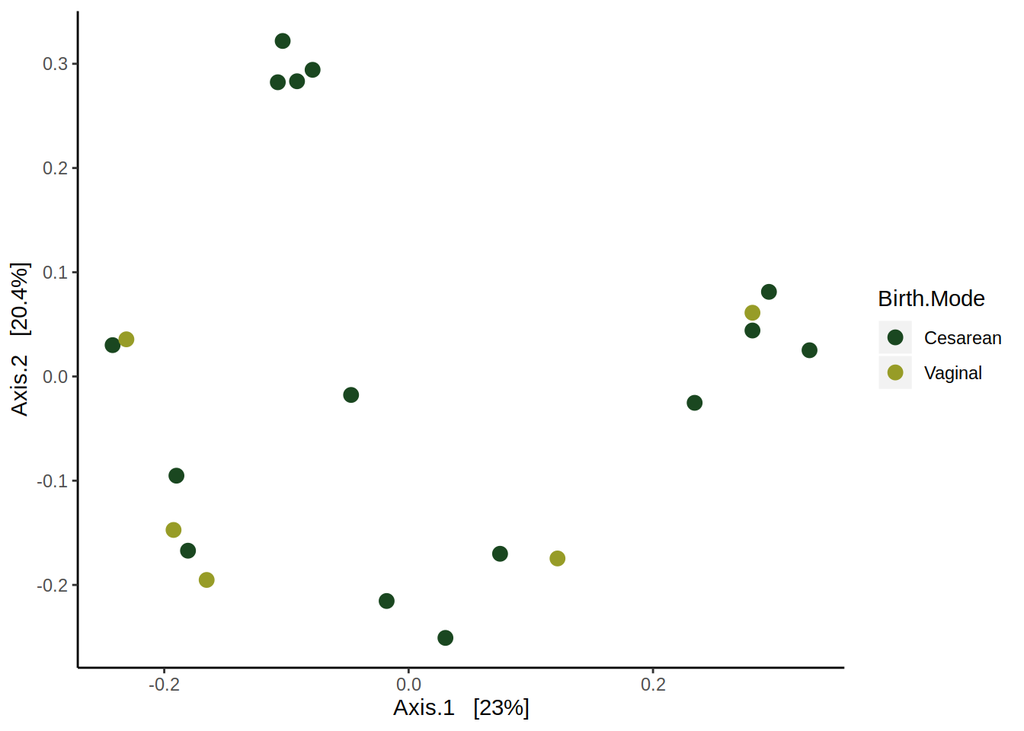

```r
ps_ranks7_plot <- plot_ordination(ps_ranks4, ordinate(ps_ranks4, "MDS", "bray"), color = "Birth.Mode") + geom_point(size = 3)

ps_ranks7_plot + scale_color_manual(values=c("#1a4720", "#979c27")) + theme(panel.grid.major = element_blank(), panel.grid.minor = element_blank(), panel.background = element_blank(), axis.line = element_line(colour = "black"))
```

```r
# Significance testing for ordination analysis (not pairwise)
metadata2 <- as(sample_data(ps_ranks4), "data.frame")
adonis(phyloseq::distance(ps_ranks4, method = "bray")~Birth.Mode, data = metadata2, p.adjust.methods= "fdr", permutations = 999)
```

```
##
## Call:
## adonis(formula = phyloseq::distance(ps_ranks4, method = "bray") ~      Birth.Mode, data = metadata2, permutations = 999, p.adjust.methods = "fdr")
##
## Permutation: free
## Number of permutations: 999
##
## Terms added sequentially (first to last)
##
##            Df SumsOfSqs MeanSqs F.Model      R2 Pr(>F)
## Birth.Mode  1   0.12232 0.12232 0.73924 0.03945   0.71
## Residuals  18   2.97850 0.16547         0.96055
## Total      19   3.10082                 1.00000
```

```r
# Beta dispersion analysis
ps.meco_dist <- phyloseq::distance(ps_ranks4, method = "bray")
sampledf3 <- data.frame(sample_data(ps_ranks4))
beta6 <- betadisper(ps.meco_dist, sampledf3$Birth.Mode, bias.adjust = TRUE)
permutest(beta6, p.adjust.methods= "fdr")
```

```
##
## Permutation test for homogeneity of multivariate dispersions
## Permutation: free
## Number of permutations: 999
##
## Response: Distances
##           Df   Sum Sq   Mean Sq      F N.Perm Pr(>F)
## Groups     1 0.006346 0.0063464 0.7341    999  0.395
## Residuals 18 0.155623 0.0086457
```

```r
# infant birth mode - six month samples
ps_ranks5 <- ps.six
abund5 <- otu_table(ps_ranks5)
abund_ranks5 <- t(apply(abund5, 1, rank))
write.table(abund_ranks5,file = "abund5_total.txt",sep = "\t")

abund_ranks5 <- abund_ranks5 - 313 # 90% of observed ASVs
abund_ranks5[abund_ranks5 < 1] <- 1
otu_table(ps_ranks5) <- otu_table(abund_ranks5, taxa_are_rows = F)
ps_ranks5
```

```
## phyloseq-class experiment-level object
## otu_table()   OTU Table:         [ 348 taxa and 20 samples ]
## sample_data() Sample Data:       [ 20 samples by 13 sample variables ]
## tax_table()   Taxonomy Table:    [ 348 taxa by 8 taxonomic ranks ]
```

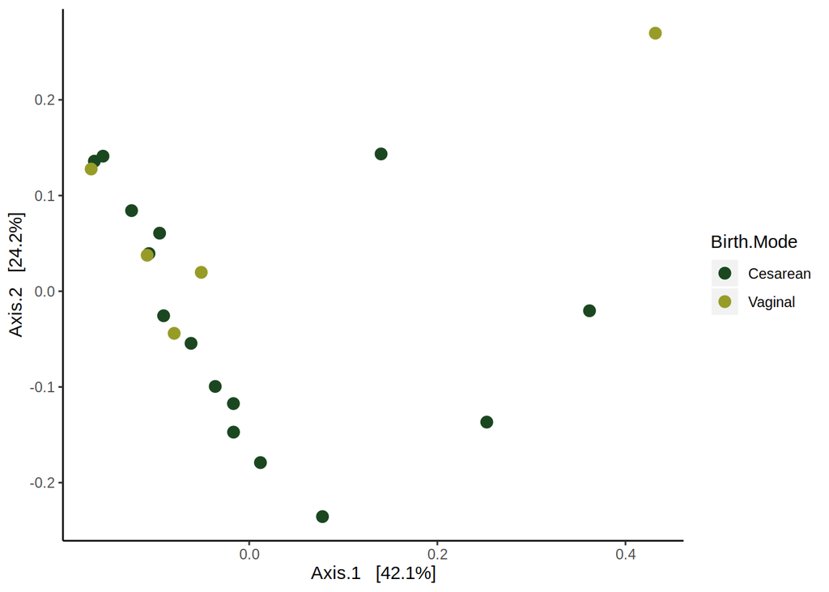

```r
ps_ranks8_plot <- plot_ordination(ps_ranks5, ordinate(ps_ranks5, "MDS", "bray"), color = "Birth.Mode") + geom_point(size = 3)

ps_ranks8_plot + scale_color_manual(values=c("#1a4720", "#979c27")) + theme(panel.grid.major = element_blank(), panel.grid.minor = element_blank(), panel.background = element_blank(), axis.line = element_line(colour = "black"))
```

```r
# Significance testing for ordination analysis (not pairwise)
metadata3 <- as(sample_data(ps_ranks5), "data.frame")
adonis(phyloseq::distance(ps_ranks5, method = "bray")~Birth.Mode, data = metadata3, p.adjust.methods= "fdr", permutations = 999)
```

```
##
## Call:
## adonis(formula = phyloseq::distance(ps_ranks5, method = "bray") ~      Birth.Mode, data = metadata3, permutations = 999, p.adjust.methods = "fdr")
##
## Permutation: free
## Number of permutations: 999
##
## Terms added sequentially (first to last)
##
##            Df SumsOfSqs  MeanSqs F.Model      R2 Pr(>F)
## Birth.Mode  1   0.06933 0.069331 0.99572 0.05242  0.381
## Residuals  18   1.25332 0.069629         0.94758
## Total      19   1.32265                  1.00000
```

```r
# Beta dispersion analysis
ps.six_dist <- phyloseq::distance(ps_ranks5, method = "bray")
sampledf4 <- data.frame(sample_data(ps_ranks5))
beta7 <- betadisper(ps.six_dist, sampledf4$Birth.Mode, bias.adjust = TRUE)
permutest(beta7, p.adjust.methods= "fdr")
```

```
##
## Permutation test for homogeneity of multivariate dispersions
## Permutation: free
## Number of permutations: 999
##
## Response: Distances
##           Df  Sum Sq   Mean Sq     F N.Perm Pr(>F)
## Groups     1 0.00327 0.0032694 0.159    999  0.685
## Residuals 18 0.37020 0.0205667
```

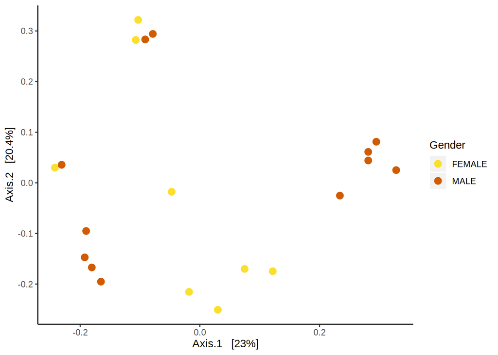

```r
# Gender - microbiome meconium samples
ps_ranks9_plot <- plot_ordination(ps_ranks4, ordinate(ps_ranks4, "MDS", "bray"), color = "Gender") + geom_point(size = 3)

ps_ranks9_plot + scale_color_manual(values=c("#fadf2d", "#d15b00")) + theme(panel.grid.major = element_blank(), panel.grid.minor = element_blank(), panel.background = element_blank(), axis.line = element_line(colour = "black"))
```

```r
# Significance testing for ordination analysis (not pairwise)
adonis(phyloseq::distance(ps_ranks4, method = "bray")~Gender, data = metadata2, p.adjust.methods= "fdr", permutations = 999)
```

```
##
## Call:
## adonis(formula = phyloseq::distance(ps_ranks4, method = "bray") ~      Gender, data = metadata2, permutations = 999, p.adjust.methods = "fdr")
##
## Permutation: free
## Number of permutations: 999
##
## Terms added sequentially (first to last)
##
##           Df SumsOfSqs MeanSqs F.Model      R2 Pr(>F)
## Gender     1    0.2281  0.2281  1.4293 0.07356  0.148
## Residuals 18    2.8727  0.1596         0.92644
## Total     19    3.1008                 1.00000
```

```r
# Beta dispersion analysis
beta8 <- betadisper(ps.meco_dist, sampledf3$Gender, bias.adjust = TRUE)
permutest(beta8, p.adjust.methods= "fdr")
```

```
##
## Permutation test for homogeneity of multivariate dispersions
## Permutation: free
## Number of permutations: 999
##
## Response: Distances
##           Df   Sum Sq   Mean Sq      F N.Perm Pr(>F)
## Groups     1 0.003872 0.0038722 0.8929    999  0.352
## Residuals 18 0.078061 0.0043367
```

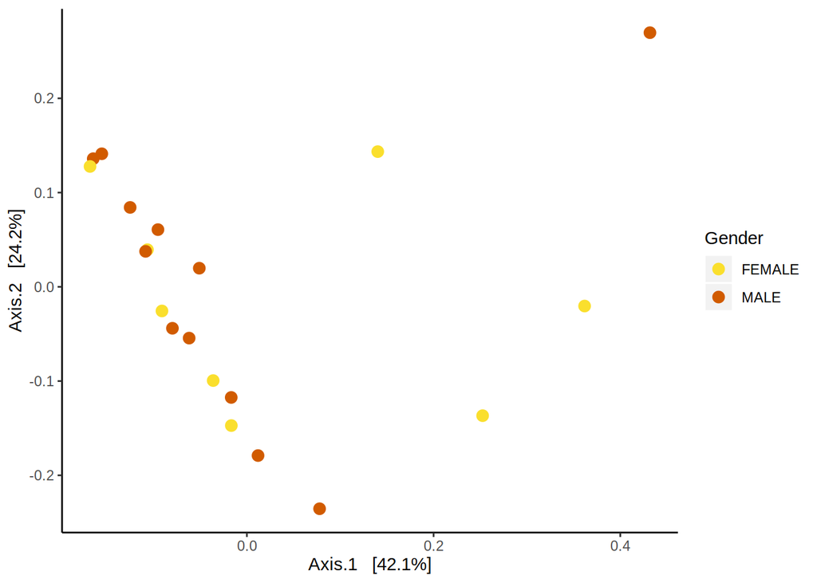

```r
# Gender - microbiome six months samples
ps_ranks10_plot <- plot_ordination(ps_ranks5, ordinate(ps_ranks5, "MDS", "bray"), color = "Gender") + geom_point(size = 3)

ps_ranks10_plot + scale_color_manual(values=c("#fadf2d", "#d15b00")) + theme(panel.grid.major = element_blank(), panel.grid.minor = element_blank(), panel.background = element_blank(), axis.line = element_line(colour = "black"))
```

```r
# Significance testing for ordination analysis (not pairwise)
adonis(phyloseq::distance(ps_ranks5, method = "bray")~Gender, data = metadata3, p.adjust.methods= "fdr", permutations = 999)
```

```
##
## Call:
## adonis(formula = phyloseq::distance(ps_ranks5, method = "bray") ~      Gender, data = metadata3, permutations = 999, p.adjust.methods = "fdr")
##
## Permutation: free
## Number of permutations: 999
##
## Terms added sequentially (first to last)
##
##           Df SumsOfSqs  MeanSqs F.Model     R2 Pr(>F)
## Gender     1   0.05039 0.050390 0.71291 0.0381  0.608
## Residuals 18   1.27226 0.070681         0.9619
## Total     19   1.32265                  1.0000
```

```r
# Beta dispersion analysis
beta9 <- betadisper(ps.six_dist, sampledf4$Gender, bias.adjust = TRUE)
permutest(beta9, p.adjust.methods= "fdr")
```

```
##
## Permutation test for homogeneity of multivariate dispersions
## Permutation: free
## Number of permutations: 999
##
## Response: Distances
##           Df Sum Sq   Mean Sq      F N.Perm Pr(>F)
## Groups     1 0.0067 0.0066998 0.3426    999   0.59
## Residuals 18 0.3520 0.0195556
```

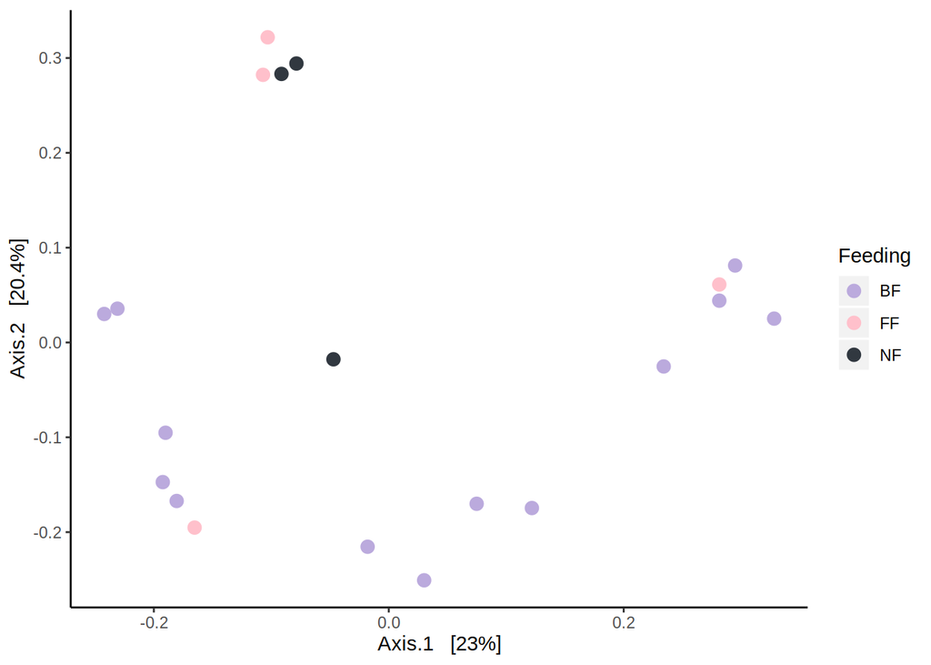

```r
# Feeding pattern - microbiome meconium samples
ps_ranks11_plot <- plot_ordination(ps_ranks4, ordinate(ps_ranks4, "MDS", "bray"), color = "Feeding") + geom_point(size = 3)

ps_ranks11_plot + scale_color_manual(values=c("#bbaadd", "#ffc0cb", "#313840")) + theme(panel.grid.major = element_blank(), panel.grid.minor = element_blank(), panel.background = element_blank(), axis.line = element_line(colour = "black"))
```

```r
# Significance testing for ordination analysis (not pairwise)
adonis(phyloseq::distance(ps_ranks4, method = "bray")~Feeding, data = metadata2, p.adjust.methods= "fdr", permutations = 999)
```

```
##
## Call:
## adonis(formula = phyloseq::distance(ps_ranks4, method = "bray") ~      Feeding, data = metadata2, permutations = 999, p.adjust.methods = "fdr")
##
## Permutation: free
## Number of permutations: 999
##
## Terms added sequentially (first to last)
##
##           Df SumsOfSqs MeanSqs F.Model      R2 Pr(>F)
## Feeding    2    0.4694 0.23470  1.5162 0.15138  0.072 .
## Residuals 17    2.6314 0.15479         0.84862
## Total     19    3.1008                 1.00000
## ---
## Signif. codes:  0 '***' 0.001 '**' 0.01 '*' 0.05 '.' 0.1 ' ' 1
```

```r
# Beta dispersion analysis
beta10 <- betadisper(ps.meco_dist, sampledf3$Feeding, bias.adjust = TRUE)
permutest(beta10, p.adjust.methods= "fdr")
```

```
##
## Permutation test for homogeneity of multivariate dispersions
## Permutation: free
## Number of permutations: 999
##
## Response: Distances
##           Df  Sum Sq   Mean Sq      F N.Perm Pr(>F)
## Groups     2 0.01007 0.0050362 0.1731    999  0.836
## Residuals 17 0.49464 0.0290966
```

Influence of feeding pattern was not tested at six months as all of the infants were partially breast fed(none of them were exclusively breast fed). The only factor that could explain variation in the maternal sample was the dietary pattern during pregnancy. So we decided to determine the significant taxa between the two groups categorized by diet in the maternal samples.

```r
# VST transformation was carried out using unpaired design, as the differences were seen independent of time point.
mother.diet.vst = phyloseq_to_deseq2(psmother.final, ~Diet) # Unpaired design
gm_mean = function(x, na.rm = TRUE){
  exp(sum(log(x[x > 0]), na.rm = na.rm) / length(x))
}
geoMeans = apply(counts(mother.diet.vst), 1, gm_mean)
mother.diet.vst = estimateSizeFactors(mother.diet.vst, geoMeans = geoMeans)
mother.diet.vst = estimateDispersions(mother.diet.vst)
abund.mother.diet = getVarianceStabilizedData(mother.diet.vst)

# replacing vst transformed count in phyloseq object
psmother.diet.vst <- psmother.final
otu_table(psmother.diet.vst) <- otu_table(abund.mother.diet, taxa_are_rows = TRUE)
psmother.diet.vst
```

```
## phyloseq-class experiment-level object
## otu_table()   OTU Table:         [ 538 taxa and 40 samples ]
## sample_data() Sample Data:       [ 40 samples by 13 sample variables ]
## tax_table()   Taxonomy Table:    [ 538 taxa by 8 taxonomic ranks ]
```

```r
# differential abundance testing
mother.diet.test <- DA.kru(psmother.diet.vst, predictor = "Diet", relative = FALSE, p.adj = "fdr")
write.csv(mother.diet.test, "mothers_diffAbund_asv_diet.csv", row.names = TRUE)
```

#### Network analysis was performed based on the Jaccard distances of the rank transformed counts of the ASVs for mother and infant samples together

```r
ps.mother.infant <- merge_phyloseq(psmother.final, psinfant.final)
ps.mother.infant
```

```
## phyloseq-class experiment-level object
## otu_table()   OTU Table:         [ 765 taxa and 80 samples ]
## sample_data() Sample Data:       [ 80 samples by 13 sample variables ]
## tax_table()   Taxonomy Table:    [ 765 taxa by 8 taxonomic ranks ]
```

```r
# rank tranformation
ps_ranks_mi <- ps.mother.infant
abund6 <- otu_table(ps_ranks_mi)
abund_ranks_mi <- t(apply(abund6, 1, rank))
write.table(abund_ranks_mi,file = "abund6_total.txt",sep = "\t")

abund_ranks_mi <- abund_ranks_mi - 688 # 90% of observed ASVs
abund_ranks_mi[abund_ranks_mi < 1] <- 1
otu_table(ps_ranks_mi) <- otu_table(abund_ranks_mi, taxa_are_rows = F)
ps_ranks_mi
```

```
## phyloseq-class experiment-level object
## otu_table()   OTU Table:         [ 765 taxa and 80 samples ]
## sample_data() Sample Data:       [ 80 samples by 13 sample variables ]
## tax_table()   Taxonomy Table:    [ 765 taxa by 8 taxonomic ranks ]
```

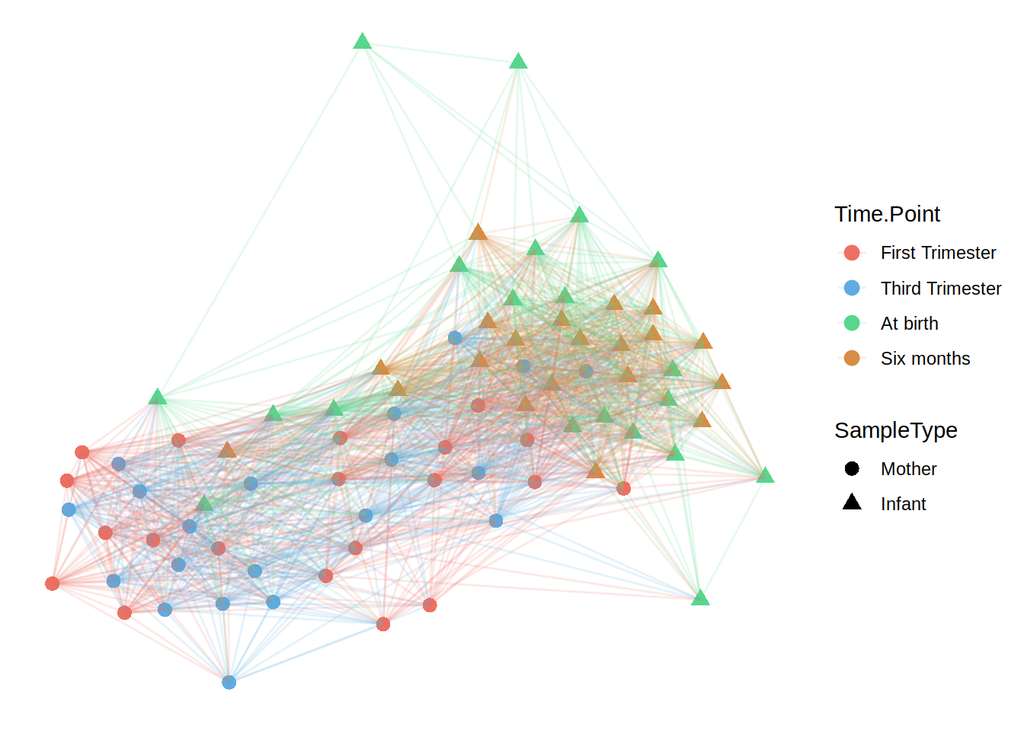

```r
# network analysis
ig <- make_network(ps_ranks_mi, max.dist=0.8, keep.isolates = FALSE, distance = "jaccard")
pl.net <- plot_network(ig, ps_ranks_mi, color="Time.Point", shape = "SampleType", label=NULL, point_size = 3, line_alpha = 0.15)
pl.net + scale_color_manual(values = c("#ec7063", "#5dade2", "#58d68d",  "#D78D43"))
```

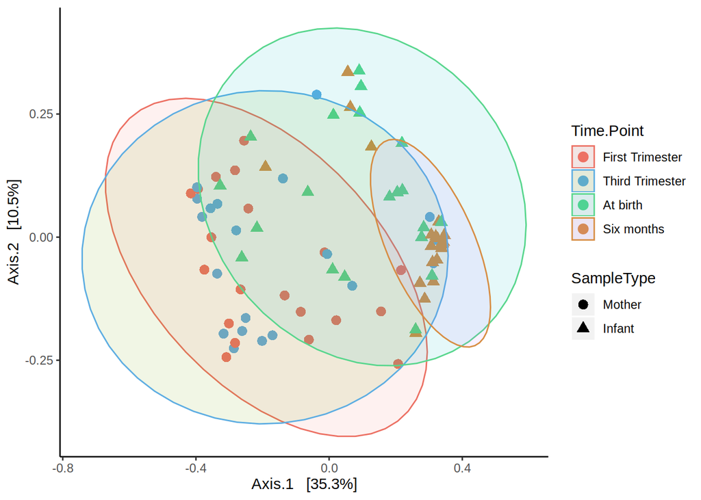

```r
# ordination analysis of maternal and infant samples together
ps_ranks13_plot <- plot_ordination(ps_ranks_mi, ordinate(ps_ranks_mi, "MDS", "bray"), color = "Time.Point", shape = "SampleType" ) + geom_point(size = 3)

ps_ranks13_plot + scale_color_manual(values=c("#ec7063", "#5dade2", "#58d68d",  "#D78D43")) + theme(panel.grid.major = element_blank(), panel.grid.minor = element_blank(), panel.background = element_blank(), axis.line = element_line(colour = "black")) + stat_ellipse(geom = "polygon", type="t", alpha=0.1, aes(fill= Time.Point))
```